# Indel Signature InsDel2a

# InsDel2a

(corresponds to 83-type signature C_ID2)

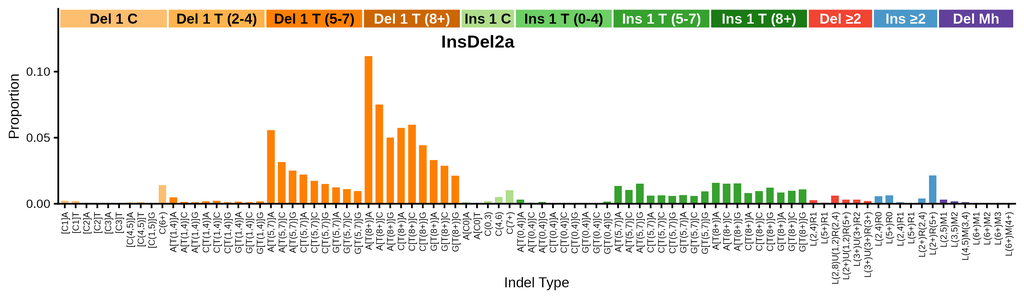

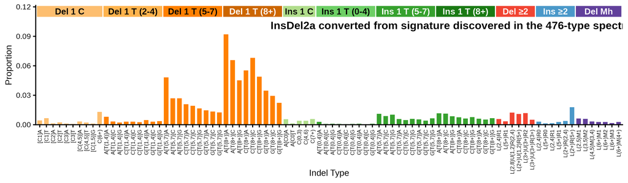

89-type spectrum of the linking tumor SP17172 | cosine similarity to InsDel2a: 0.971

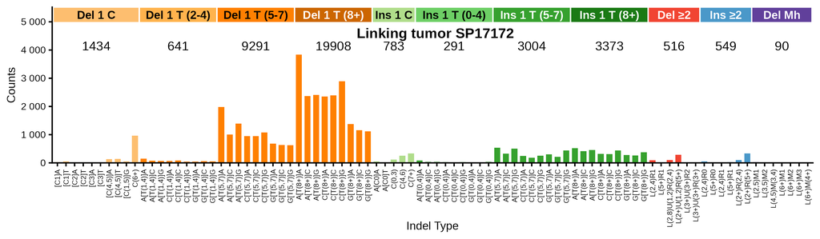

**Click to view decomposition of the linking tumor spectrum**

Partial mutation signature of SP17172 due to InsDel2a

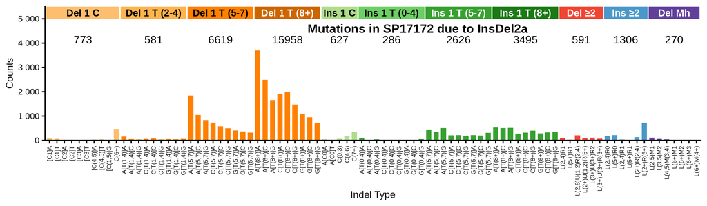

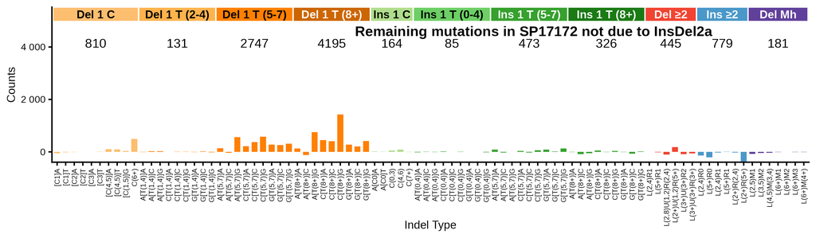

**Per-channel residual breakdown**

| Channel | Spectrum | Sig_Count | Residual | Sig_Prop |
| --- | --- | --- | --- | --- |
| [Del(C):R1]A | 28 | 75.3 | -47.3 | 0.00227 |
| [Del(C):R1]T | 51 | 68.0 | -17 | 0.00205 |
| [Del(C):R2]A | 13 | 21.7 | -8.7 | 0.00066 |
| [Del(C):R2]T | 21 | 19.7 | 1.3 | 0.00060 |
| [Del(C):R3]A | 7 | 8.8 | -1.8 | 0.00026 |
| [Del(C):R3]T | 23 | 16.9 | 6.1 | 0.00051 |
| [Del(C):R(4,5)]A | 135 | 34.7 | 100.3 | 0.00105 |
| [Del(C):R(4,5)]T | 138 | 41.9 | 96.1 | 0.00126 |
| [Del(C):R(1,5)]G | 53 | 17.0 | 36 | 0.00051 |
| Del(C):R(6,9) | 965 | 469.3 | 495.7 | 0.01416 |
| A[Del(T):R(1,4)]A | 149 | 158.3 | -9.3 | 0.00478 |
| A[Del(T):R(1,4)]C | 78 | 48.8 | 29.2 | 0.00147 |
| A[Del(T):R(1,4)]G | 69 | 39.0 | 30 | 0.00118 |
| C[Del(T):R(1,4)]A | 66 | 62.7 | 3.3 | 0.00189 |
| C[Del(T):R(1,4)]C | 84 | 74.8 | 9.2 | 0.00226 |
| C[Del(T):R(1,4)]G | 45 | 37.2 | 7.8 | 0.00112 |
| G[Del(T):R(1,4)]A | 44 | 56.2 | -12.2 | 0.00170 |
| G[Del(T):R(1,4)]C | 57 | 41.3 | 15.7 | 0.00125 |
| G[Del(T):R(1,4)]G | 49 | 63.0 | -14 | 0.00190 |
| A[Del(T):R(5,7)]A | 1981 | 1844.2 | 136.8 | 0.05566 |
| A[Del(T):R(5,7)]C | 1006 | 1043.6 | -37.6 | 0.03150 |
| A[Del(T):R(5,7)]G | 1395 | 831.6 | 563.4 | 0.02510 |
| C[Del(T):R(5,7)]A | 946 | 732.0 | 214 | 0.02209 |
| C[Del(T):R(5,7)]C | 947 | 578.2 | 368.8 | 0.01745 |
| C[Del(T):R(5,7)]G | 1075 | 493.6 | 581.4 | 0.01490 |
| G[Del(T):R(5,7)]A | 684 | 411.3 | 272.7 | 0.01241 |
| G[Del(T):R(5,7)]C | 633 | 369.7 | 263.3 | 0.01116 |
| G[Del(T):R(5,7)]G | 624 | 314.9 | 309.1 | 0.00950 |
| A[Del(T):R(8,)]A | 3835 | 3702.6 | 132.4 | 0.11175 |
| A[Del(T):R(8,)]C | 2368 | 2490.5 | -122.5 | 0.07517 |

[output cut: 59 more lines]

**Click to view similar signatures from Koh et al.**

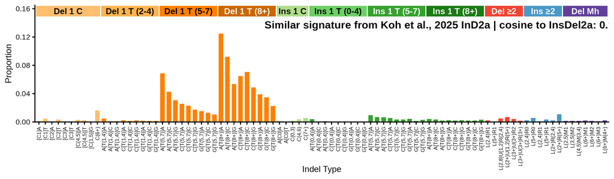

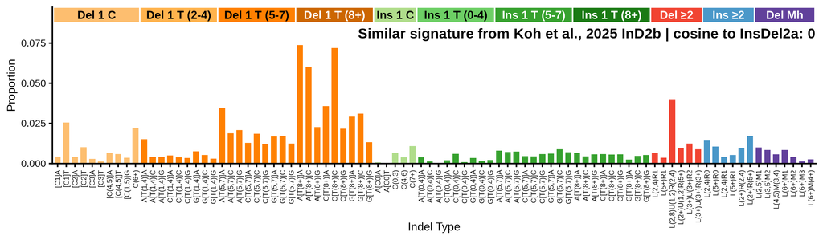

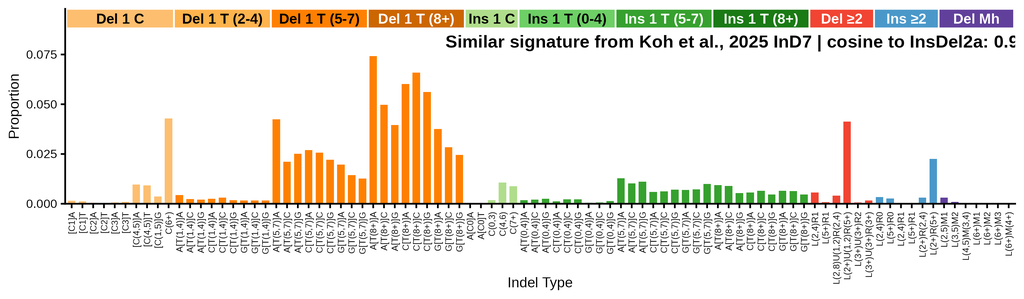

## 476-type representations corresponding to InsDel2a

Extracted 476-type signature corresponding to InsDel2a

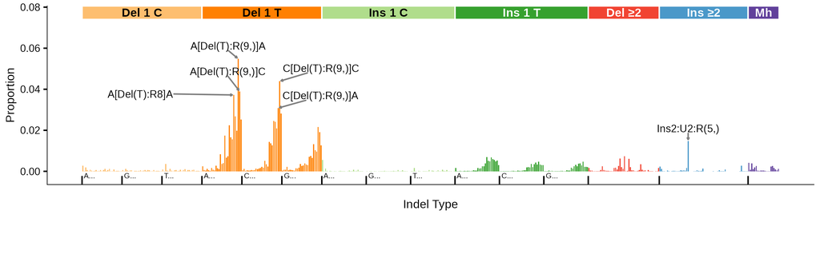

476-type spectrum of the linking tumor SP17172; cosine similarity to the extracted 476-type signature is 0.9726

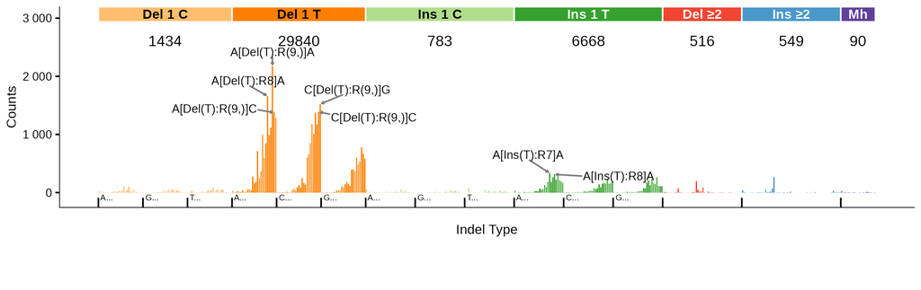

476-type spectrum of best 476-type matching tumor CPCT02011050T; cosine similarity to the extracted 476-type signature is 0.9802

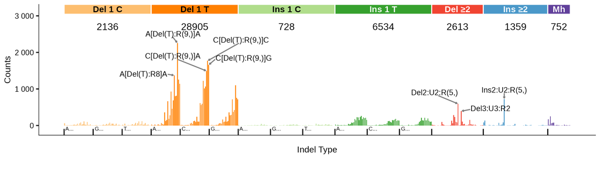

## 83-type signature corresponding to InsDel2a (C_ID2)

**Note**

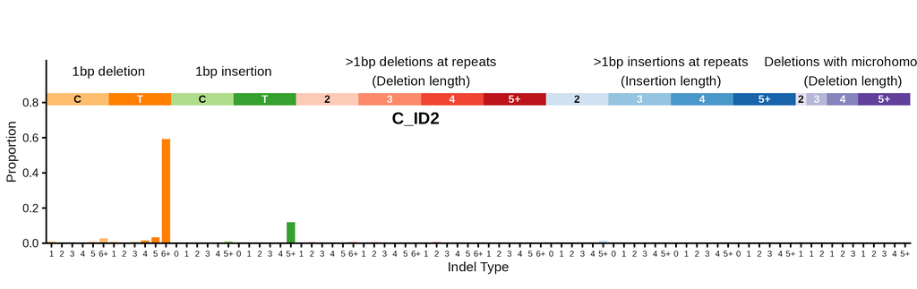

**Click here to see with insertions and deletions of T in long poly-T suppressed**

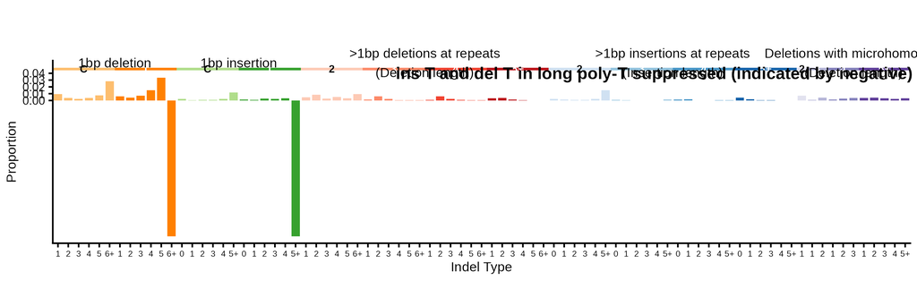

83-type signature converted from signature discovered in the 476-type spectra (using bipartite matching optimization) | cosine similarity to C_ID2: 0.9994

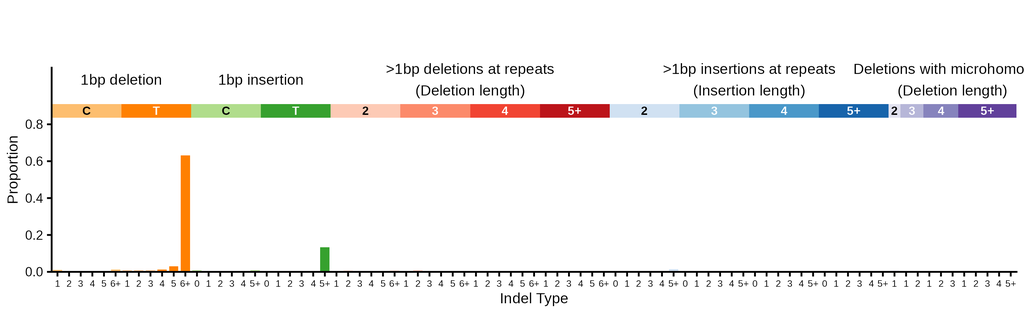

**Click here to see with insertions and deletions of T in long poly-T suppressed**

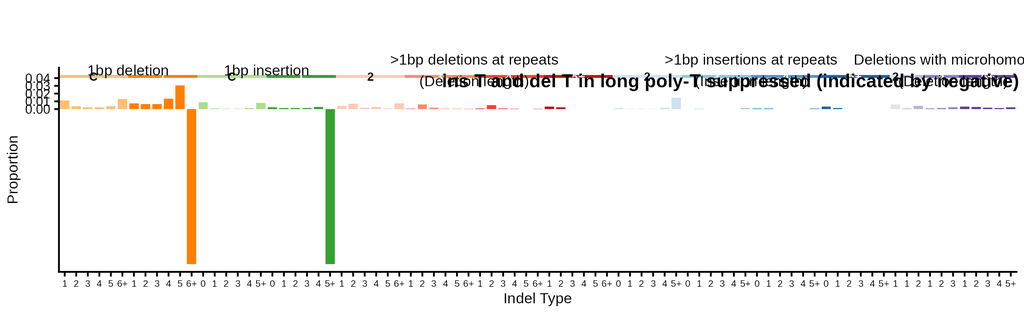

**Click to see flow diagrams: 476-type to 83-type collapse**

These Sankey diagrams show how the 476-type mutation categories are redistributed to 83-type categories using bipartite matching. We only show the diagrams for insertions or deletions of > 1 base because it is for these indels that 476-type categories map to > 1 83-type category.

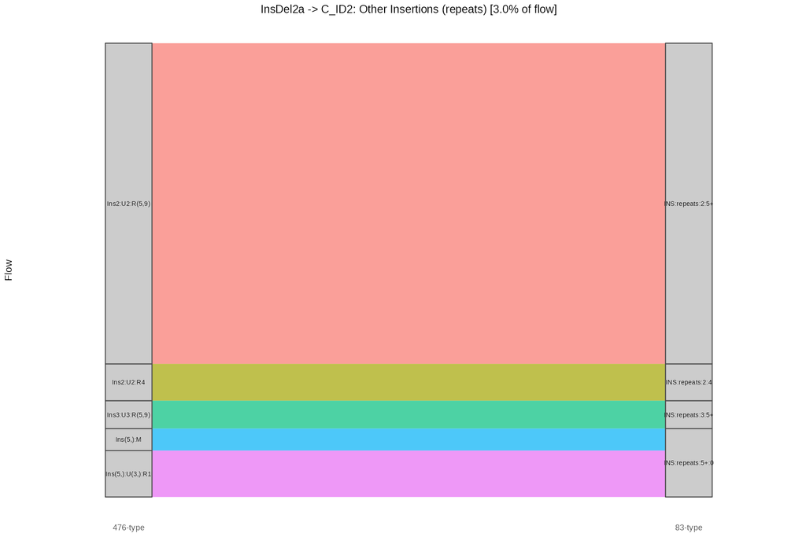

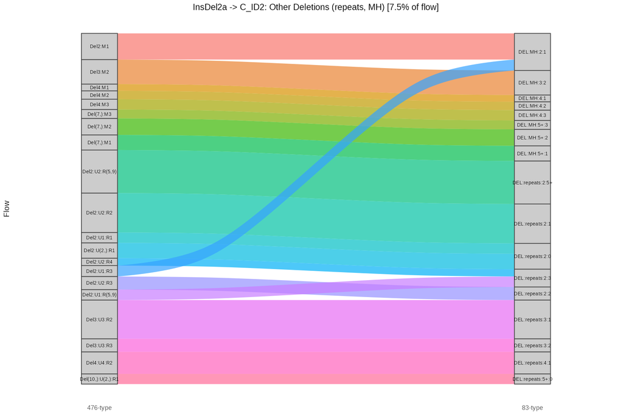

83-type spectrum of the linking tumor SP17172 | cosine similarity to C_ID2: 0.9986

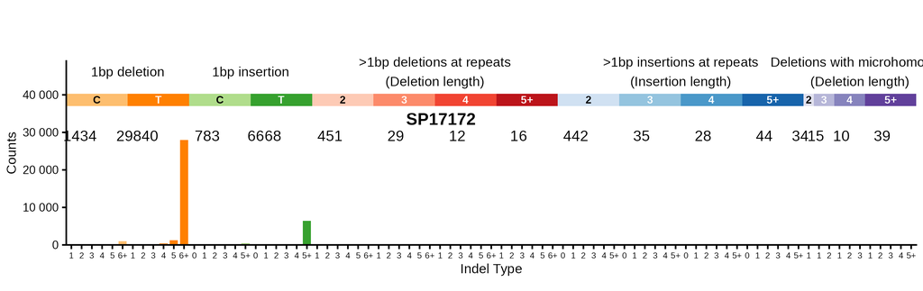

**Click here to see with insertions and deletions of T in long poly-T suppressed**

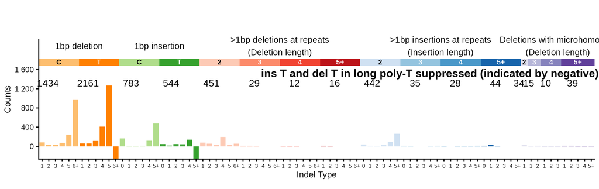

83-type spectrum of best 83-type matching tumor DRUP01080031T | cosine similarity to C_ID2: 0.9996

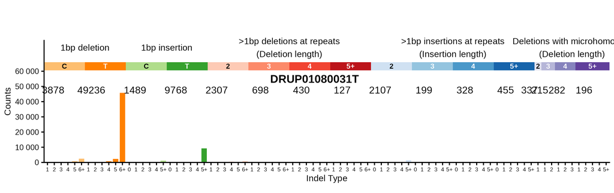

**Click here to see with insertions and deletions of T in long poly-T suppressed**

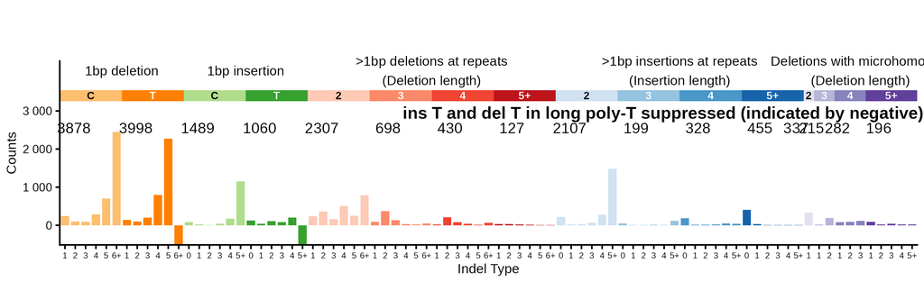

### Similar COSMIC signatures

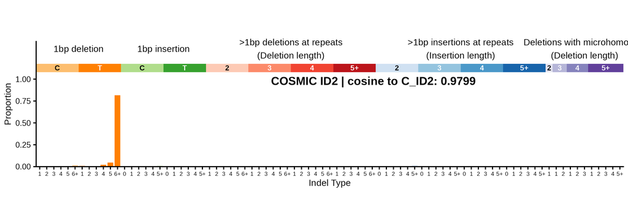

**Click here to see with insertions and deletions of T in long poly-T suppressed**

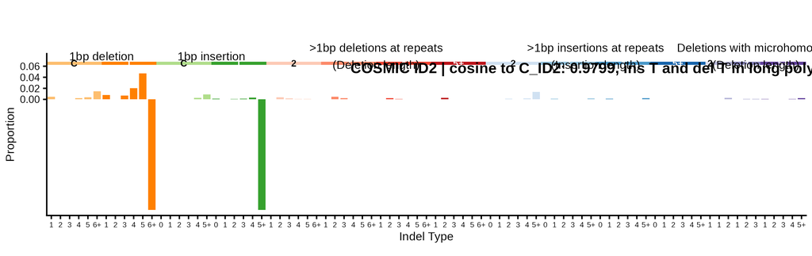

### Similar signatures from Jin et al. 2024

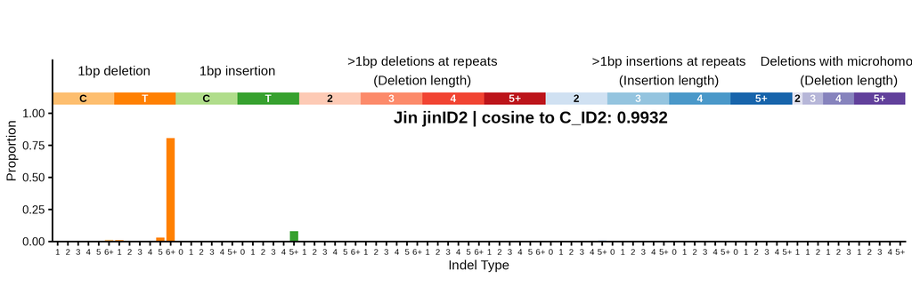

**Click here to see with insertions and deletions of T in long poly-T suppressed**

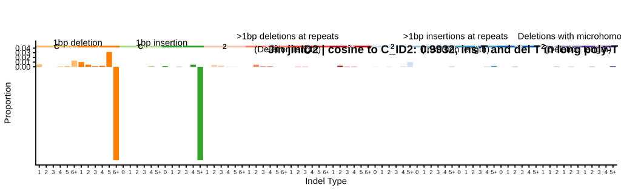